# How to Put Equations into Evernote

andreacirilloac

2014-09-11

## Problem

Some time ago I was looking for an easy way to put some math writing within my Evernote notes trough my Mac device. Even if there is no official solution to the problem and the feature request is still pending within Evernote dedicated forum, I finally came out with a very simple way to solve your problem out.

## Solution

This way is called Grapher, a Mac OS built-in application for visualising math stuffs.

## Tutorial

Here below a simple tutorial:

### 1. find Grapher among your applications

You can either search for it within Spotlight or using the launchpad.

[figure not shown]

### 2. write the equation

you would like to put into your Evernote note.

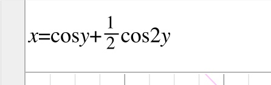

### 3. copy the equation as [TIFF](http://http://it.wikipedia.org/wiki/Tagged_Image_File_Format)

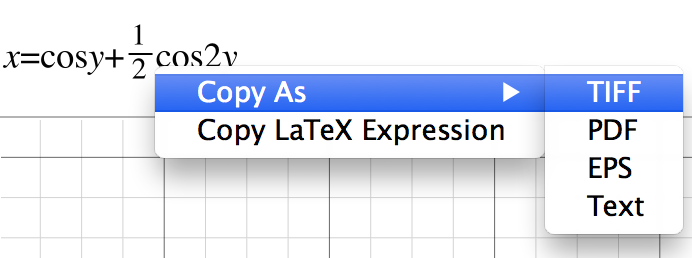

## 4. paste the equation into Evernote

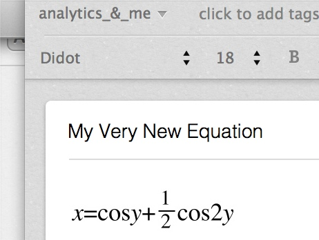

And that’s it!

I think this trick is very useful when you have some “heavy” equations that would not be clear enough if it would just be written in simple text.

Sharing the post on [Google +](https://plus.google.com/u/0/+AndreaCirilloAC/posts/SGCWuFYcyDy?cfem=1)I have received the good advice to use [daum equation editor](https://itunes.apple.com/it/app/daum-equation-editor/id540665783?mt=12), specifically aimed at writing equations.

I think the Grapher advantage is that is a built-in application, nevertheless I’m really grateful to [Roberta Normano](https://plus.google.com/u/0/114794468455584031025/about)for the tip.

Did you came out with any other way to address the problem?